# CC02: Practical Exercises - Part 3

Netherlands Institute for Health Sciences (NIHES), 2018-2019

## Practical exercise 23: Stratified analysis of cross tabulations

We will use the data from the study about oesophageal cancer. This data is stored in the BD2.SAV file. This file does not contain individual data but “tabulated” data. To use these data correctly the records have to be “weighted”.

### Question a

Open the data set and inspect what this “tabulated” data looks like.

#### Code

```r
bd2 <- read.spss("./data/Bd2.sav", to.data.frame = TRUE) # read the data and store
dim(bd2)       # What are the dimensions of the dataset?
head(bd2)      # Print the first six rows of the data
summary(bd2)   # Summarizes the variables
```

#### Hints

In order to inspect the data frame, you can for example 1) look at the dimensions of the data frame (`dim`), 2) check the header of the data frame (`head`), or 3) summarize the data frame (`summary`).

#### Output

```r
bd2 <- read.spss("./data/Bd2.sav", to.data.frame = TRUE)
dim(bd2)       # What are the dimensions of the dataset?
```

```
## [1] 22  4
```

```r
head(bd2)      # Print the first six rows of the data
```

```
##   DISEASE                  ALC NUMBER    AGEGR
## 1 control 0-79 g alcohol daily     31 >= 75 yr
## 2 control 0-79 g alcohol daily     88 65-74 yr
## 3 control 0-79 g alcohol daily    106 25-34 yr
## 4 control 0-79 g alcohol daily    138 45-54 yr
## 5 control 0-79 g alcohol daily    139 55-64 yr
## 6 control 0-79 g alcohol daily    164 35-44 yr
```

```r
summary(bd2)   # Summarizes the variables
```

```
##     DISEASE                     ALC         NUMBER            AGEGR
##  control:11   0-79 g alcohol daily:11   Min.   :  1.00   25-34 yr:3
##  case   :11   > 80 g alcohol daily:11   1st Qu.: 11.25   35-44 yr:4
##                                         Median : 26.50   45-54 yr:4
##                                         Mean   : 44.32   55-64 yr:4
##                                         3rd Qu.: 40.50   65-74 yr:4
##                                         Max.   :164.00   >= 75 yr:3
```

#### Discussion

As you can see, this data frame consists of 4 columns and 22 rows. Every row contains a certain group of people, for example people who do not have oesophageal cancer, drink 0-79 grams of alcohol daily and are at least 75 years of age. The column “NUMBER” tells you how many people have these characteristics. Later on in this exercise, you will take into account that these numbers differ.

### Question b

Find the (crude) odds ratio of alcohol use for oesophageal cancer.

#### Code

```r
crosstab <- xtabs(bd2$NUMBER ~ bd2$ALC + bd2$DISEASE)
crosstab # to inspect what the cross tab looks like
odds.ratio(crosstab)
```

#### Hints

You can use the function `xtabs()` to make a cross table. In this `xtabs()` function define the variable that defines the exposure `+` the variable that defines the outcome, this will resemble the cross table from exercise 9c.  
Because this data set contains tabulated data, you also need to take into account the numbers per group. You can include this weighting in the `xtabs()` function. The weighting variable plus the `~` symbol should be placed before the two variables you are interested in. For example: `crosstab <- xtabs(data$NUMBERS ~ data$EXPOSURE + data$OUTCOME)`  
Subsequently, you can use the function `odds.ratio()` from the package `samplesizeMCH` to get the crude odds ratio.

#### Output

```r
crosstab <- xtabs(bd2$NUMBER ~ bd2$ALC + bd2$DISEASE)  # create a table
crosstab # to inspect what the cross table looks like
```

```
##                       bd2$DISEASE
## bd2$ALC                control case
##   0-79 g alcohol daily     666  104
##   > 80 g alcohol daily     109   96
```

```r
odds.ratio(crosstab) # the odds ratio
```

```
## [1] 5.640085
```

#### Discussion

The crude odds ratio for oesophageal cancer in alcohol users versus non-alcohol users is 5.64. This means that individuals that are exposed to more than 80 gram alcohol daily have a 5.64 times higher odds to get oesophageal cancer compared to individuals that consume 0-79 gram alcohol on a daily basis.

### Question c

Now we will examine this odds ratio in different age groups. To do so, create a three-dimensional cross table with age group as third variable.  
Why does `R` give infinite (“Inf”) odds ratios of the first and last age group? What can you say about these odds ratios?  
Write down the odds ratios that can be computed for the different age groups.

#### Code

```r
crosstab_strat <- xtabs(bd2$NUMBER ~ bd2$ALC + bd2$DISEASE + bd2$AGEGR) # create a table
crosstab_strat  # print the cross table
apply(crosstab_strat, 3, odds.ratio) # use the apply function to get the OR
```

#### Hints

You can use the same `xtabs()` function for the three-dimensional cross table. The only thing you need to do, is add another variable after a `+` symbol.  
To get the odds ratio for every age group separately, you can use the `apply()` function, which can apply a function (in this case retrieving the odds ratio) to multiple tables. For this `apply()` function, you need to define three arguments: `apply(X, MARGIN, FUN)`.

`X` is the array you want to apply the function to, in this case your three-dimensional cross table.

`MARGIN` is telling the function what part of the array this function should be applied to - in this case you should define it as `3` because it should be applied to the whole tables.

`FUN` defines the function, in this case the function for retrieving the odds ratio.

#### Output

```r
crosstab_strat <- xtabs(bd2$NUMBER ~  bd2$ALC + bd2$DISEASE + bd2$AGEGR)
crosstab_strat
```

```
## , , bd2$AGEGR = 25-34 yr
##
##                       bd2$DISEASE
## bd2$ALC                control case
##   0-79 g alcohol daily     106    0
##   > 80 g alcohol daily       9    1
##
## , , bd2$AGEGR = 35-44 yr
##
##                       bd2$DISEASE
## bd2$ALC                control case
##   0-79 g alcohol daily     164    5
##   > 80 g alcohol daily      26    4
##
## , , bd2$AGEGR = 45-54 yr
##
##                       bd2$DISEASE
## bd2$ALC                control case
##   0-79 g alcohol daily     138   21
##   > 80 g alcohol daily      29   25
##
## , , bd2$AGEGR = 55-64 yr
##
##                       bd2$DISEASE
## bd2$ALC                control case
##   0-79 g alcohol daily     139   34
##   > 80 g alcohol daily      27   42
##
## , , bd2$AGEGR = 65-74 yr
##
##                       bd2$DISEASE
## bd2$ALC                control case
##   0-79 g alcohol daily      88   36
##   > 80 g alcohol daily      18   19
##
## , , bd2$AGEGR = >= 75 yr
##
##                       bd2$DISEASE
## bd2$ALC                control case
##   0-79 g alcohol daily      31    8
##   > 80 g alcohol daily       0    5
```

```r
apply(crosstab_strat, 3, odds.ratio)
```

```
## 25-34 yr 35-44 yr 45-54 yr 55-64 yr 65-74 yr >= 75 yr
##      Inf 5.046154 5.665025 6.359477 2.580247      Inf
```

```r
mantelhaen.test(crosstab_strat)
```

```
##
##  Mantel-Haenszel chi-squared test with continuity correction
##
## data:  crosstab_strat
## Mantel-Haenszel X-squared = 83.215, df = 1, p-value < 2.2e-16
## alternative hypothesis: true common odds ratio is not equal to 1
## 95 percent confidence interval:
##  3.562131 7.467743
## sample estimates:
## common odds ratio
##          5.157623
```

### Question d

Retrieve the Cochran’s and Mantel-Haenszel statistic and perform a test for homogeneity of the odds ratio.

Which null hypothesis is tested with “Conditional Independence” and which null hypothesis with “Homogeneity”? Explain the numbers of degrees of freedom (df equal to 1 and 5, respectively) related to testing either hypothesis.

Is it justified to assume that there is one common odds ratio? Why or why not?

Find the estimated common odds ratio and its confidence interval. Compare this adjusted odds ratio with the answer from question b and with the odds ratios in the age groups.

#### Code

```r
mantelhaen.test(crosstab_strat)
BreslowDayTest(crosstab_strat)
```

#### Hints

You can calculate the Mantel-Haenszel statistic using the function `mantelhaen.test()`.  
You can use the Breslow-Day test to test for homogeneity of the odds ratios, for example with the `BreslowDayTest()` function from the `DescTools` package.  
In question c, you have already written the code to extract the statistics for the test for conditional independence, as well as the adjusted odds ratio and its confidence interval.

#### Output

```r
mantelhaen.test(crosstab_strat)
```

```
##
##  Mantel-Haenszel chi-squared test with continuity correction
##
## data:  crosstab_strat
## Mantel-Haenszel X-squared = 83.215, df = 1, p-value < 2.2e-16
## alternative hypothesis: true common odds ratio is not equal to 1
## 95 percent confidence interval:
##  3.562131 7.467743
## sample estimates:
## common odds ratio
##          5.157623
```

```r
BreslowDayTest(crosstab_strat)
```

```
##
##  Breslow-Day test on Homogeneity of Odds Ratios
##
## data:  crosstab_strat
## X-squared = 9.3234, df = 5, p-value = 0.09684
```

#### Discussion

As you can see in the Mantel-Haenszel output, the common adjusted odds ratio is 5.16 (95% confidence interval 3.56-7.47). This is a bit lower than the crude odds ratio of 5.64 (question b). If you look at the cross tables from question c, you can see that this probably has to do with the unequal distribution of age. Most patients are in age category 3 and 4 which also have the highest odds ratios.  
The null hypothesis for “Conditional Independence” is testing whether the odds ratio is equal to 1 in each of the subgroups. Put it otherwise: it tests whether x and y are conditionally independent, $OR_{xy}(k)=1$ for $k=1,2,...,k$. Therefore, only one parameter is estimated and only 1 degree of freedom is used. If you look at the Mantel-Haenszel output, you can see that the p-value is < 2.2e-16, so H0 is rejected ($OR_{xy}$ is not equal to 1).  
The null hypothesis for “Homogeneity” is that the association, and thus the odds ratio, is homogeneous across groups. Put it otherwise: it tests whether there is a homogeneous x-y association, $OR_{xy}(1)=OR_{xy}(2)=...=OR_{xy}(k)$, with $df=k-1$ (in this case 5). If you look at the output from the Breslow-Day test, you can see that the p-value is 0.097, which means that H0 is not rejected. You can assume that there is one common odds ratio.

## Practical exercise 24: Direct pooling in a meta-analysis

At a certain stage in the course of an IVF (in vitro fertilisation) treatment an agonist or an antagonist is administered. In the table below the results are given of three clinical trials in which the use of an agonist was compared with an antagonist with respect to the ongoing (= at least for 12 weeks) pregnancy rate.

```
##
##
## Table: Trial 1
##
##                           antagonist (Ganirelix)   agonist (Busereline)
## ------------------------  -----------------------  ---------------------
## no. patients              487                      243
## no. ongoing pregnancies   99                       62
##
##
## Table: Trial 2
##
##                           antagonist (Ganirelix)   agonist (Busereline)
## ------------------------  -----------------------  ---------------------
## no. patients              188                      85
## no. ongoing pregnancies   51                       28
##
##
## Table: Trial 3
##
##                           antagonist (Ganirelix)   agonist (Busereline)
## ------------------------  -----------------------  ---------------------
## no. patients              115                      36
## no. ongoing pregnancies   26                       11
```

As effect measure we use the risk difference, i.e. the difference in pregnancy rate between both treatments. To analyse the data, we use the “pooling with inverse squared standard errors” method. We recommend to do the computations by hand, using a calculator. However, it is also possible to use `R` as a kind of pocket calculator. If you choose to use `R`, open the data file IVF.SAV.

### Question a

Compute variables for the risks and risk differences of the trials. Also compute the weights and the weighted risk differences.

#### Code

```r
ivf <- read.spss("./data/IVF.sav", to.data.frame = TRUE)
ivf  # print the data frame

# compute risks of pregnancy in both the antagonist (anta) and the agonist(agon) group
ivf$riskanta <- ivf$ANTAPREG / ivf$ANTA  # risk among anta are stored as the new variable riskanta
ivf$riskago <- ivf$AGONPREG / ivf$AGON   # risk among agon are stored as the new variable riskago
ivf[, c("riskanta", "riskago")]          # print the risks

# compute risk difference, its SE and weight
ivf$riskdiff <- ivf$riskago - ivf$riskanta   # calculate the risk differences between agon vs anta
ivf$se_diff <- sqrt(ivf$riskanta * (1 - ivf$riskanta) /
                       ivf$ANTA + ivf$riskago * (1 - ivf$riskago) / ivf$AGON) #calculate the SE of the risk difference
ivf$weight <- 1 / ivf$se_diff ^ 2         # calculate the weight
ivf[, c("riskdiff", "se_diff", "weight")] # print the new variables

# computing weighted risk differences for each trial
ivf$riskdiff_weighted <- ivf$riskdiff * ivf$weight
ivf[, "riskdiff_weighted"] # print the value

sum_weight <- sum(ivf$weight)
sum_weight
sum_riskdiff_weighted <- sum(ivf$riskdiff_weighted)
sum_riskdiff_weighted
```

#### Hints

The following variables are needed for all three trials: the risk differences between agonist and antagonist, their standard errors and weights.  
You can use the `sum()` function to get the sum of the weights and weighted risk differences.

#### Output

```r
ivf <- read.spss("./data/IVF.sav", to.data.frame = TRUE)
ivf # to see what the data looks like
```

```
##   TRIAL ANTA AGON ANTAPREG AGONPREG
## 1     1  487  243       99       62
## 2     2  188   85       51       28
## 3     3  115   36       26       11
```

```r
# compute risks
ivf$riskanta <- ivf$ANTAPREG / ivf$ANTA
ivf$riskago <- ivf$AGONPREG / ivf$AGON
ivf[, c("riskanta", "riskago")] # print the risks
```

```
##    riskanta   riskago
## 1 0.2032854 0.2551440
## 2 0.2712766 0.3294118
## 3 0.2260870 0.3055556
```

```r
# compute risk differences, its SE and weight
ivf$riskdiff <- ivf$riskago - ivf$riskanta  # risk difference
ivf$se_diff <- sqrt(ivf$riskanta * (1 - ivf$riskanta) /
                       ivf$ANTA + ivf$riskago * (1 - ivf$riskago) / ivf$AGON) # SE risk difference
ivf$weight <- 1 / ivf$se_diff ^ 2  # weighted
ivf[, c("riskdiff", "se_diff", "weight")] # print the new variables
```

```
##     riskdiff    se_diff   weight
## 1 0.05185861 0.03338635 897.1441
## 2 0.05813517 0.06041803 273.9472
## 3 0.07946860 0.08611444 134.8491
```

```r
# computing weighted risk differences for each trial
ivf$riskdiff_weighted <- ivf$riskdiff * ivf$weight
ivf[, "riskdiff_weighted"] # print the value
```

```
## [1] 46.52465 15.92597 10.71627
```

```r
sum_weight <- sum(ivf$weight)
sum_weight
```

```
## [1] 1305.94
```

```r
sum_riskdiff_weighted <- sum(ivf$riskdiff_weighted)
sum_riskdiff_weighted
```

```
## [1] 73.16688
```

#### Discussion

We observe that in the three trials, the group receiving an agonist had a higher risk of pregnancy than the antagonist group. The risk was 5.18%, 5.81% and 7.94% higher for trial 1, 2 and 3 respectively. The calculated weights don’t have a meaningful interpretation for now, but we can observe that trial 1 has the biggest weight and this corresponds to the biggest sample size compared to the other two trials. These weights will help us calculate the pooled risk difference in the following question.

### Question b

Use the sums calculated in question a to create new variables: pooled risk difference and its standard error. Of course these variables are constant for the three trials. What is the associated approximate 95% confidence interval?

#### Code

```r
riskdiff_pool <- sum_riskdiff_weighted / sum_weight
riskdiff_pool

se_riskdiff_pool <- sqrt(1 / sum_weight)
se_riskdiff_pool

riskdiff_pool_low <- riskdiff_pool - 1.96 * se_riskdiff_pool
riskdiff_pool_low
riskdiff_pool_up  <- riskdiff_pool + 1.96 * se_riskdiff_pool
riskdiff_pool_up
```

#### Hints

First, to calculate the pooled risk difference you will want to divide the `sum_riskdiff_weighted` over the `sum_weight`. Second, calculate the SE by calculating the squared root (`sqrt`) of 1 over the `sum_weight`. Last, use the pooled risk difference and SE you just calculated to estimate de lower and upper confidence intervals.

#### Output

```r
riskdiff_pool <- sum_riskdiff_weighted / sum_weight
riskdiff_pool
```

```
## [1] 0.0560262
```

```r
se_riskdiff_pool <- sqrt(1 / sum_weight)
se_riskdiff_pool
```

```
## [1] 0.02767186
```

```r
riskdiff_pool_low <- riskdiff_pool - 1.96 * se_riskdiff_pool
riskdiff_pool_low
```

```
## [1] 0.001789362
```

```r
riskdiff_pool_up  <- riskdiff_pool + 1.96 * se_riskdiff_pool
riskdiff_pool_up
```

```
## [1] 0.110263
```

#### Discussion

When we pool the three trials, we observe that the group receiving an agonist had a 5.60% (95% confidence interval 0.18% - 11.02%) higher risk of pregnancy than the antagonist group.

### Question c

Test the hypothesis of homogeneity of risk differences. State your conclusion.

#### Code

```r
ivf$test_h0    <- (ivf$riskdiff - riskdiff_pool) ^ 2 / ivf$se_diff ^ 2
test_statistic <- sum(ivf$test_h0)
test_statistic
```

#### Hints

The null hypothesis is riskdiff_1 = riskdiff_2 = riskdiff_3. The test statistic is the sum of test_h0.

#### Output

```r
ivf$test_h0    <- (ivf$riskdiff - riskdiff_pool) ^ 2 / ivf$se_diff ^ 2
test_statistic <- sum(ivf$test_h0)
test_statistic
```

```
## [1] 0.09090654
```

#### Discussion

The null hypothesis states that the risk differences across trials are homogeneous. The test statistic is the sum of `test_h0`, so 0.09 in this example. The distribution is Chi-square with k-1 df. If you look in the table, 0.09 with 2 df implies p>0.05 so the null hypothesis is not rejected, i.e. risk differences are homogeneous.

## Practical exercise 25: Survival Analysis

In this exercise we will use the data set Colonsel.sav.

### Question a

Open and save the dataset as a data frame. Describe the data frame and variables, pay special attention to the variable that represents the time until event (“SURV”). Also, observe how many subjects had the event and how many were censored (“STATUS”).

#### Code

```r
survival <- as.data.frame(read.spss("./data/Colonsel.sav", use.value.labels = FALSE))
dim(survival)     # look at the dimensions of the data
head(survival)    # look at the first 6 rowns
summary(survival) # get a summary of the variables
qplot(survival$SURV, geom = "histogram") # create a histogram
```

#### Hints

When you import the dataset as a data frame, add the argument `use.value.labels = FALSE`, otherwise `R` will import the data frame with the labels (text) for each variable and not with the numeric value.  
You can start by checking the dimensions of the data frame. Then, observe the header and see how the variables were coded. Later you can summarize each variable, be careful on how to interpret the variables that are categorical. For the time variable, observe graphically how the distribution behaves using a histogram.

#### Output

```r
survival <- as.data.frame(read.spss("./data/Colonsel.sav", use.value.labels = FALSE))
dim(survival)     # look at the dimensions of the data
```

```
## [1] 111  13
```

```r
head(survival)    # look at the first 6 rowns
```

```
##   AGE SEX CHANCE PATTERN BLDLOSS STOMACHE WGHTLOSS ILEUS STATUS STAGE LOC
## 1  70   1      0       0       0        0        0     0      1     2   2
## 2  53   0      0       0       0        0        0     0      0     2   1
## 3  66   1      0       0       0        1        1     0      1     2   2
## 4  70   0      0       0       0        0        0     1      1     2   3
## 5  59   0      0       0       1        0        0     0      0     1   2
## 6  65   1      1       0       0        0        0     0      0     3   1
##   SURV OPYEAR
## 1 3.00     78
## 2 3.66     78
## 3 4.07     77
## 4 0.03     78
## 5 3.42     78
## 6 4.01     78
```

```r
summary(survival) # get a summary of the variables
```

```
##       AGE             SEX             CHANCE           PATTERN
##  Min.   :50.00   Min.   :0.0000   Min.   :0.00000   Min.   :0.0000
##  1st Qu.:59.00   1st Qu.:0.0000   1st Qu.:0.00000   1st Qu.:0.0000
##  Median :64.00   Median :0.0000   Median :0.00000   Median :1.0000
##  Mean   :62.77   Mean   :0.4685   Mean   :0.08108   Mean   :0.5495
##  3rd Qu.:67.00   3rd Qu.:1.0000   3rd Qu.:0.00000   3rd Qu.:1.0000
##  Max.   :70.00   Max.   :1.0000   Max.   :1.00000   Max.   :1.0000
##     BLDLOSS          STOMACHE         WGHTLOSS          ILEUS
##  Min.   :0.0000   Min.   :0.0000   Min.   :0.0000   Min.   :0.00000
##  1st Qu.:0.0000   1st Qu.:0.0000   1st Qu.:0.0000   1st Qu.:0.00000
##  Median :0.0000   Median :0.0000   Median :0.0000   Median :0.00000
##  Mean   :0.4414   Mean   :0.4054   Mean   :0.3243   Mean   :0.06306
##  3rd Qu.:1.0000   3rd Qu.:1.0000   3rd Qu.:1.0000   3rd Qu.:0.00000
##  Max.   :1.0000   Max.   :1.0000   Max.   :1.0000   Max.   :1.00000
##      STATUS           STAGE            LOC             SURV
##  Min.   :0.0000   Min.   :1.000   Min.   :1.000   Min.   : 0.000
##  1st Qu.:0.0000   1st Qu.:1.000   1st Qu.:2.000   1st Qu.: 2.525
##  Median :1.0000   Median :2.000   Median :3.000   Median : 4.120
##  Mean   :0.5315   Mean   :1.919   Mean   :2.658   Mean   : 4.872
##  3rd Qu.:1.0000   3rd Qu.:2.000   3rd Qu.:3.500   3rd Qu.: 7.355
##  Max.   :1.0000   Max.   :3.000   Max.   :4.000   Max.   :11.460
##      OPYEAR
##  Min.   :71.0
##  1st Qu.:73.0
##  Median :74.0
##  Mean   :74.4
##  3rd Qu.:77.0
##  Max.   :78.0
```

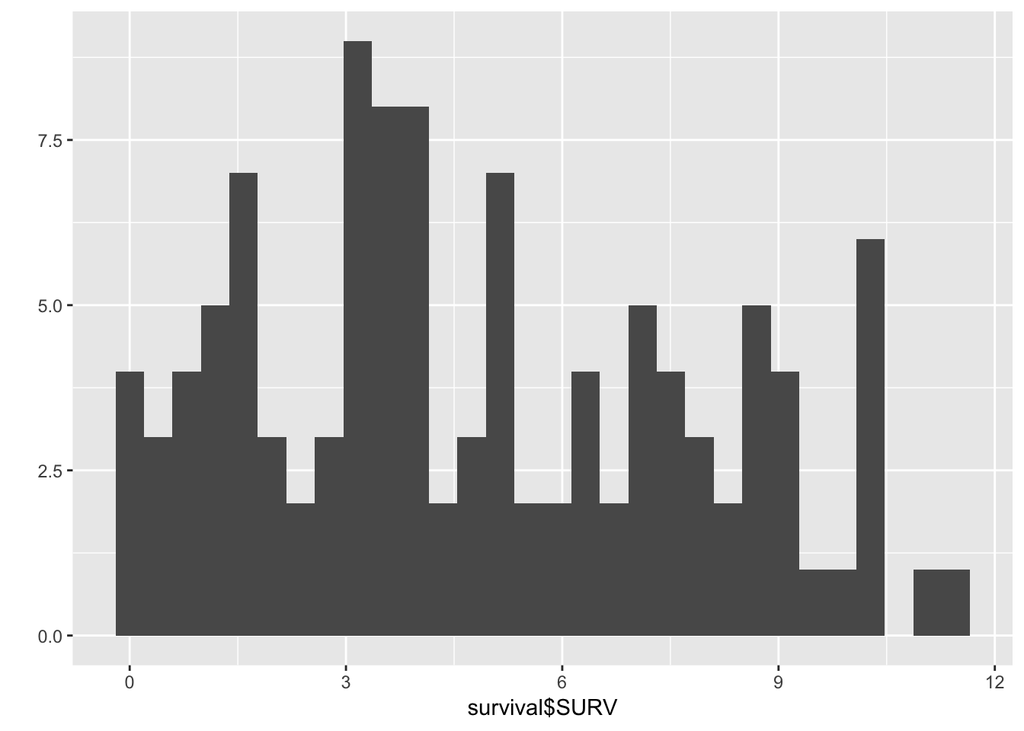

```r
qplot(survival$SURV, geom = "histogram") # create a histogram
```

#### Discussion

This data frame consists of 13 columns and 111 rows. Every row represents an individual included in the study. From the total 111 subjects included, 52 were censored during follow-up and 59 (53%) died. The subjects were followed for a median of 4.12 years (IQR: 2.52 - 7.35).  
Extra tip: usually you will have to calculate the follow-up time using the date of entering the study and the date of event/censoring. Once you have calculated the time - for example by subtracting the latest minus the earliest date - make sure you describe the variable before using it. Having negative times or extreme outliers might be telling you that something was wrong in the dates of that observation. Not fixing this beforehand can lead to future problems when you start with the survival analysis.

### Question b

Make a Kaplan-Meier (KM) life table for the whole group of 111 patients. You can do this using the `survival` package.  
What is the estimated two-year survival percentage with 95% confidence interval? If possible, read from the table the 25th, the 50th and the 75th percentile of the survival time. Check that the 50th percentile is the same as the median mentioned below the survival table. The mean survival time is not very useful because of its rather artificial interpretation, why?

#### Code

```r
fit <- survfit(Surv(SURV, STATUS) ~ 1, data = survival) #create the table
summary(fit) #print the table
```

#### Hints

To create the Kaplan-Meier (KM) life table you have to fit a model using the `survfit()` function. Inside the function you will need to specify the time and status variable: `survfit(Surv(SURV, STATUS) ~ 1, data = survival)`. By default, the function will consider the status coded as 1 as the event and 0 as the censored. Save the model as an object and use the `summary()` function to obtain the KM life table.  
To identify the two-year survival probability, follow to the time column and look for the row that points the last time before 2 years (in this case time point 1.87). To identify the time of 75th and 50th percentile of survival, follow the column with the survival probability to get to the closest values to 0.75 and 0.5 and look at the time point in the corresponding row. The 50th percentile will correspond to the median time. The 25th percentile of survival cannot be estimated because more than 25% survived until the end of follow-up.

#### Output

```r
fit <- survfit(Surv(SURV, STATUS) ~ 1, data = survival)
summary(fit)
```

```
## Call: survfit(formula = Surv(SURV, STATUS) ~ 1, data = survival)
##
##  time n.risk n.event survival std.err lower 95% CI upper 95% CI
##  0.00    111       1    0.991 0.00897        0.974        1.000
##  0.03    110       1    0.982 0.01263        0.958        1.000
##  0.05    109       1    0.973 0.01539        0.943        1.000
##  0.08    108       1    0.964 0.01769        0.930        0.999
##  0.27    107       1    0.955 0.01969        0.917        0.994
##  0.35    106       1    0.946 0.02146        0.905        0.989
##  0.45    105       1    0.937 0.02307        0.893        0.983
##  0.68    104       1    0.928 0.02455        0.881        0.977
##  0.88    103       2    0.910 0.02718        0.858        0.965
##  0.91    101       1    0.901 0.02836        0.847        0.958
##  0.99    100       1    0.892 0.02947        0.836        0.952
##  1.19     99       1    0.883 0.03052        0.825        0.945
##  1.24     98       1    0.874 0.03151        0.814        0.938
##  1.28     97       1    0.865 0.03245        0.804        0.931
##  1.32     96       1    0.856 0.03334        0.793        0.924
##  1.47     95       2    0.838 0.03499        0.772        0.909
##  1.56     93       1    0.829 0.03575        0.762        0.902
##  1.62     92       1    0.820 0.03648        0.751        0.895
##  1.63     91       1    0.811 0.03717        0.741        0.887
##  1.71     90       1    0.802 0.03784        0.731        0.879
##  1.72     89       1    0.793 0.03847        0.721        0.872
##  1.87     88       1    0.784 0.03907        0.711        0.864
##  2.09     87       1    0.775 0.03965        0.701        0.857
##  2.15     86       1    0.766 0.04020        0.691        0.849
##  2.22     85       1    0.757 0.04072        0.681        0.841
##  2.47     84       1    0.748 0.04122        0.671        0.833
##  2.58     83       1    0.739 0.04170        0.661        0.825
##  2.60     82       1    0.730 0.04215        0.652        0.817
##  2.95     81       1    0.721 0.04258        0.642        0.809
##  3.00     80       1    0.712 0.04299        0.632        0.801
##  3.09     79       1    0.703 0.04338        0.623        0.793
##  3.11     78       1    0.694 0.04375        0.613        0.785
##  3.17     76       1    0.685 0.04412        0.603        0.777
##  3.28     74       1    0.675 0.04448        0.594        0.768
##  3.32     72       1    0.666 0.04484        0.584        0.760
##  3.37     71       1    0.657 0.04518        0.574        0.751
##  3.56     66       1    0.647 0.04558        0.563        0.742
##  3.81     63       1    0.636 0.04600        0.552        0.733
##  4.01     61       1    0.626 0.04641        0.541        0.724
##  4.04     59       1    0.615 0.04682        0.530        0.714
##  4.07     58       2    0.594 0.04755        0.508        0.695
##  4.12     56       1    0.583 0.04787        0.497        0.685
##  4.49     54       1    0.573 0.04819        0.486        0.675
##  4.76     52       1    0.562 0.04850        0.474        0.665
##  4.86     51       1    0.551 0.04878        0.463        0.655
##  5.06     48       1    0.539 0.04910        0.451        0.645
##  5.34     43       1    0.527 0.04953        0.438        0.633
##  6.06     40       1    0.513 0.05001        0.424        0.621
##  6.17     39       1    0.500 0.05043        0.411        0.610
##  6.33     38       1    0.487 0.05080        0.397        0.598
##  6.52     36       1    0.474 0.05116        0.383        0.585
##  6.90     34       1    0.460 0.05151        0.369        0.573
##  7.13     33       1    0.446 0.05180        0.355        0.560
##  7.24     31       1    0.431 0.05209        0.340        0.547
##  7.95     22       1    0.412 0.05328        0.320        0.531
##  8.87     15       1    0.384 0.05636        0.288        0.512
```

#### Discussion

The KM life table presents at every time point the number of individuals at risk, the number of events and the survival probability (standard error and confidence intervals) until the next time point.  
The estimated survival at 2 years is 78.4% (95%CI 71.1 - 86.4%), 75% survival probability corresponds to 2.47 years and the median time of survival is 6.17 years.  
The mean survival is artificial because 10 years is the end of follow-up.  
If you are interested in observing the number of people that were censored at each time, you may need to use the `surv_summary()` function. You can place the fitted model inside the function and save it as a different object. Observe the object.

```r
res.sum <- surv_summary(fit)
res.sum
```

```
##      time n.risk n.event n.censor      surv     std.err     upper
## 1    0.00    111       1        0 0.9909910 0.009049866 1.0000000
## 2    0.03    110       1        0 0.9819820 0.012857018 1.0000000
## 3    0.05    109       1        0 0.9729730 0.015819300 1.0000000
## 4    0.08    108       1        0 0.9639640 0.018351713 0.9992676
## 5    0.27    107       1        0 0.9549550 0.020614394 0.9943285
## 6    0.35    106       1        0 0.9459459 0.022689216 0.9889616
## 7    0.45    105       1        0 0.9369369 0.024624695 0.9832658
## 8    0.68    104       1        0 0.9279279 0.026452388 0.9773060
## 9    0.88    103       2        0 0.9099099 0.029866052 0.9647625
## 10   0.91    101       1        0 0.9009009 0.031480009 0.9582368
## 11   0.99    100       1        0 0.8918919 0.033045440 0.9515696
## 12   1.19     99       1        0 0.8828829 0.034569822 0.9447763
## 13   1.24     98       1        0 0.8738739 0.036059248 0.9378696
## 14   1.28     97       1        0 0.8648649 0.037518764 0.9308598
```

[output cut: 197 more lines]

### Question c

Make a plot of the survival curve. What do the `+'s` mean?

#### Code

```r
ggsurvplot(fit)
```

#### Hints

To graph the Kaplan Meier curve, use the `ggsurvplot()` function. You only need to include the name of object with the fitted model we used before.  
As you can see, by default the graph presents the survival curve with confidence intervals.

#### Output

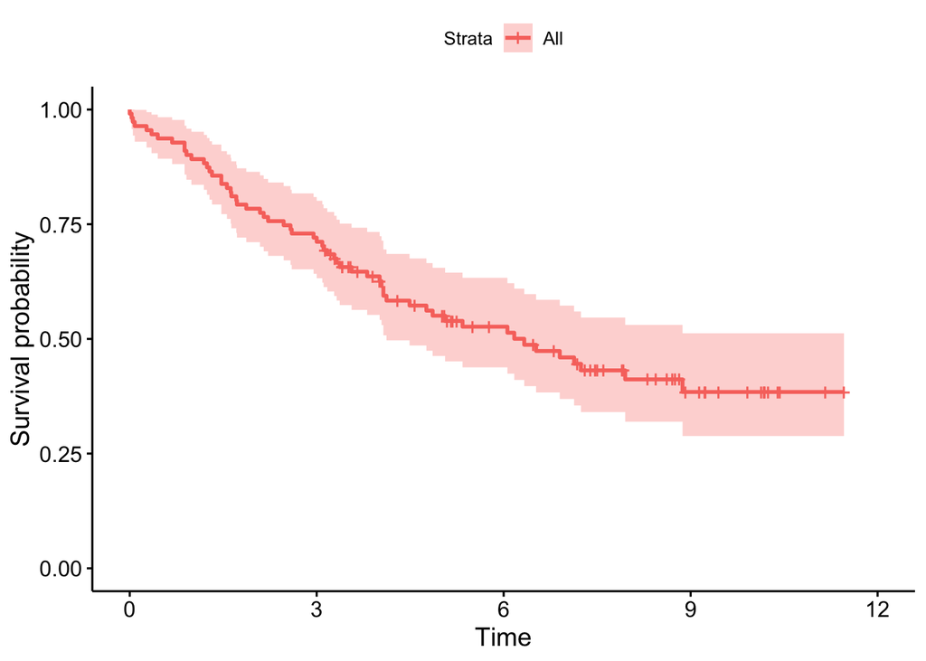

```r
ggsurvplot(fit)
```

#### Discussion

The graph represents the table we previously described. If we follow the Y axis until the survival probability of 0.50 and look in the graph to the corresponding time point on the X axis, we can see that the median time of survival is around 6 years.  
The ‘+’ represents the individuals censored at each time point.

### Question d

In this part of the exercise we are going to explore different characteristics to add to the previous graph. Add a risk table that counts how many people were still alive at the intervals graphed. Draw a line to clearly identify the median survival time and explore different colours for the curves.

#### Code

```r
ggsurvplot(fit,                  # plot a list of survfit objects
       conf.int = TRUE,          # include the confidence interval
       risk.table = TRUE,        # add a risk table
       surv.median.line = "hv",  # add the medicaun survival line
       palette = c("#91D1C2B2")) # change the colour of the line
```

#### Hints

You can add different arguments inside the `ggsurvplot()` function to personalize the graph. The 95% confidence limits of the survival function are graphed by the argument `conf.int = TRUE`, this is the default. The number of individuals at risk by time can be obtained using the `risk.table = TRUE` argument. The line that helps you identify the median survival time is created by the argument `surv.median.line`. Allowed values include one of `c("none", "hv", "h", "v")`, where v: vertical, h:horizontal and hv:both. To change the colour, use the `palette` argument and the colour names from ggplot.

#### Output

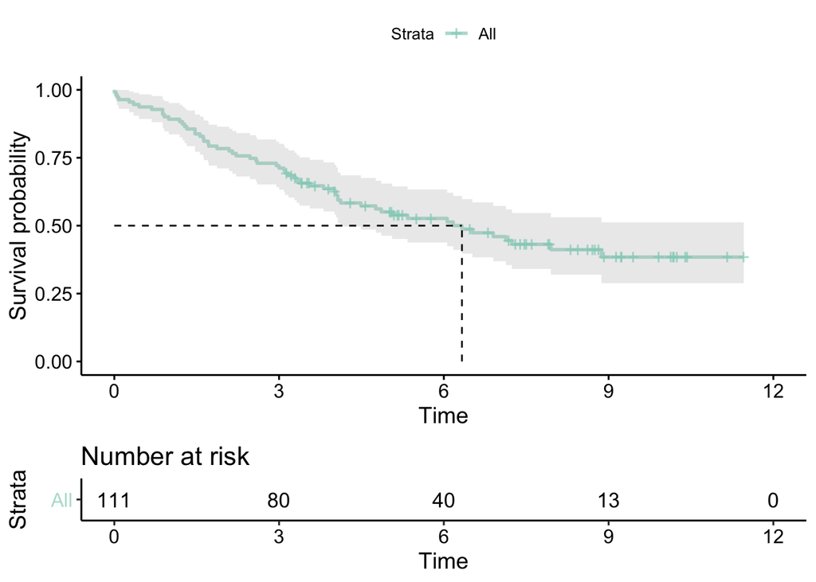

```r
ggsurvplot(fit,                  # plot a list of survfit objects
       conf.int = TRUE,          # include the confidence interval
       risk.table = TRUE,        # add a risk table
       surv.median.line = "hv",  # add the medicaun survival line
       palette = c("#91D1C2B2")) # change the colour of the line
```

### Question e

The actuarial method differs from the Kaplan-Meier method by taking larger intervals. The number and width of the intervals can be chosen by yourself. Make an actuarial life table, specifying intervals of one year (0 through 11 by 1). Also ask for a plot of the survival and hazard function. Study carefully the output of the life table. The proportion surviving, which stands for the estimated conditional probability of surviving an interval, is computed as (1 the number of events/number of patients at risk), where the patients censored during the interval are counted as half the interval at risk.

#### Code

```r
summary(fit, times = c(0:11))

hazard <- summary(fit, times = c(0:11))$n.event / summary(fit, times = c(0:11))$n.risk
plot(summary(fit, times = c(0:11))$time - 1 , hazard, type = "p", ylab = "Hazard", xlab = "Survival since operation (years)", xlim = c(0:10))
```

#### Hints

To create the actuarial table, the simplest way is to add a time argument when evaluating the summary of the fitted model. We can do this by defining the specific `time` as a vector `c(0:11)`.  
Subsequently, in order to create the hazard plot, you need to calculate the hazard at each time point: number of events / number of people at risk. After that, you can plot the hazard against the survival time since operation using the `plot` function. `type = "p"` will give a plot with points of the hazard at each time point.

#### Output

```r
summary(fit, times = c(0:11))
```

```
## Call: survfit(formula = Surv(SURV, STATUS) ~ 1, data = survival)
##
##  time n.risk n.event survival std.err lower 95% CI upper 95% CI
##     0    111       1    0.991 0.00897        0.974        1.000
##     1     99      11    0.892 0.02947        0.836        0.952
##     2     87      12    0.784 0.03907        0.711        0.864
##     3     80       8    0.712 0.04299        0.632        0.801
##     4     61       8    0.636 0.04600        0.552        0.733
##     5     50       8    0.551 0.04878        0.463        0.655
##     6     40       2    0.527 0.04953        0.438        0.633
##     7     33       5    0.460 0.05151        0.369        0.573
##     8     21       3    0.412 0.05328        0.320        0.531
##     9     13       1    0.384 0.05636        0.288        0.512
##    10      8       0    0.384 0.05636        0.288        0.512
##    11      2       0    0.384 0.05636        0.288        0.512
```

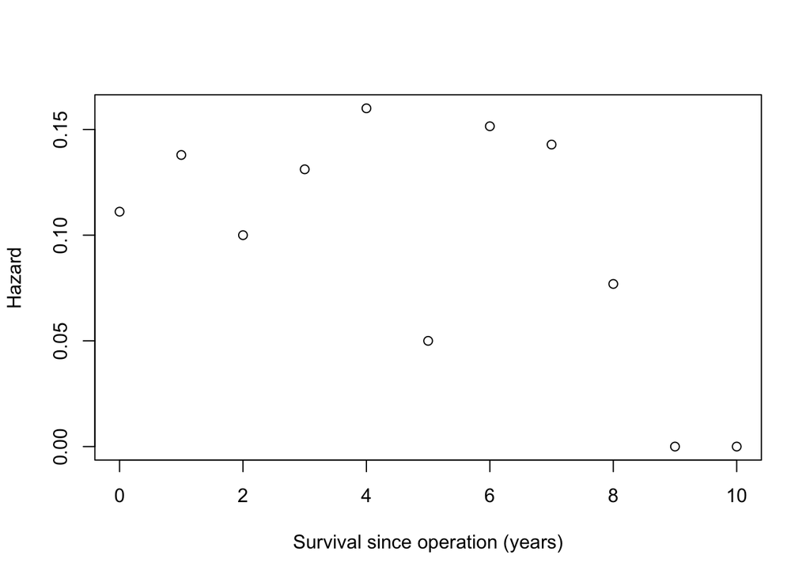

```r
hazard <- summary(fit, times = c(0:11))$n.event / summary(fit, times = c(0:11))$n.risk
plot(summary(fit, times = c(0:11))$time - 1 , hazard, type = "p", ylab = "Hazard", xlab = "Survival since operation (years)", xlim = c(0,10))
```

### Question f

Make survival plots for men and women and test whether they are significantly different or not. What is your conclusion? Do the same for the localisation of the tumour and for the Duke stage.

#### Code

```r
fit_sex <- survfit(Surv(SURV, STATUS) ~ SEX, data = survival)
summary(fit_sex)
summary(fit_sex, time = c(10))

ggsurvplot(fit_sex,
      conf.int = TRUE,
      risk.table = TRUE,
      risk.table.col = "strata",
      risk.table.height = 0.3,
      surv.median.line = "hv",
      linetype = "strata",
      palette = c("#E7B800", "#2E9FDF"),
      legend.labs = c("Male", "Female"))

survdiff(Surv(SURV, STATUS) ~ SEX, data = survival)

fit_loc <- survfit(Surv(SURV, STATUS) ~ LOC, data = survival)
summary(fit_loc)
summary(fit_loc, time = c(10))

ggsurvplot(fit_loc,
      conf.int = TRUE,
      risk.table = TRUE,
      risk.table.col = "strata",
      risk.table.height = 0.35,
      legend.labs = c("coecum", "colon transcendent", "colon descendent", "rectum"))

survdiff(Surv(SURV, STATUS) ~ LOC, data = survival)

fit_stage <- survfit(Surv(SURV, STATUS) ~ STAGE, data = survival)
summary(fit_stage)
summary(fit_stage, time = c(10))

ggsurvplot(fit_stage,
      conf.int = TRUE,
      risk.table = TRUE,
      risk.table.col = "strata",
      risk.table.height = 0.35,
      legend.labs = c("A", "B", "C"))

survdiff(Surv(SURV, STATUS) ~ STAGE, data = survival)
```

#### Hints

To create curves for different groups, add the factor variable in the `survfit` model, after the `~`, save it as a new model. To graph the model, use `ggsurvplot`, you may have to add arguments to have some of the extra features by groups. These arguments are `risk.table.col = "strata"` to add a risk table by groups, `risk.table.height` will adapt the size of the risk table, in case you have many groups you will want to increase the height of it. `linetype = "strata"` creates the median survival lines for each group. Finally, you may have to add the colours you need for the different groups if you intend to use `palette`.  
To obtain the log-rank test you need to use the `survdiff` function, the expression of the model will be the same as with `survfit`.

#### Output

```r
fit_sex <- survfit(Surv(SURV, STATUS) ~ SEX, data = survival)
summary(fit_sex)
```

```
## Call: survfit(formula = Surv(SURV, STATUS) ~ SEX, data = survival)
##
##                 SEX=0
##  time n.risk n.event survival std.err lower 95% CI upper 95% CI
##  0.03     59       1    0.983  0.0168        0.951        1.000
##  0.08     58       1    0.966  0.0236        0.921        1.000
##  0.27     57       1    0.949  0.0286        0.895        1.000
##  0.35     56       1    0.932  0.0327        0.870        0.999
##  0.45     55       1    0.915  0.0363        0.847        0.989
##  0.68     54       1    0.898  0.0393        0.824        0.979
##  0.88     53       1    0.881  0.0421        0.803        0.968
##  0.99     52       1    0.864  0.0446        0.781        0.956
##  1.19     51       1    0.847  0.0468        0.761        0.944
##  1.28     50       1    0.831  0.0488        0.740        0.932
##  1.47     49       1    0.814  0.0507        0.720        0.919
##  1.56     48       1    0.797  0.0524        0.700        0.906
##  1.62     47       1    0.780  0.0540        0.681        0.893
##  1.63     46       1    0.763  0.0554        0.662        0.879
##  1.71     45       1    0.746  0.0567        0.643        0.866
##  2.09     44       1    0.729  0.0579        0.624        0.852
##  2.47     43       1    0.712  0.0590        0.605        0.837
##  3.09     42       1    0.695  0.0599        0.587        0.823
##  3.11     41       1    0.678  0.0608        0.569        0.808
##  3.32     38       1    0.660  0.0618        0.549        0.793
##  3.37     37       1    0.642  0.0626        0.531        0.778
##  3.56     34       1    0.623  0.0636        0.510        0.761
##  3.81     31       1    0.603  0.0646        0.489        0.744
##  4.01     30       1    0.583  0.0655        0.468        0.727
##  4.49     28       1    0.562  0.0664        0.446        0.709
##  4.86     27       1    0.542  0.0671        0.425        0.690
##  5.34     22       1    0.517  0.0685        0.399        0.670
##  6.06     21       1    0.492  0.0695        0.373        0.649
##  6.17     20       1    0.468  0.0702        0.348        0.628
##  6.52     19       1    0.443  0.0707        0.324        0.606
##  6.90     17       1    0.417  0.0712        0.298        0.583
##  7.13     16       1    0.391  0.0714        0.273        0.559
##  7.24     14       1    0.363  0.0715        0.247        0.534
##  7.95      9       1    0.323  0.0741        0.206        0.506
##
##                 SEX=1
```

[output cut: 10 more lines]

```
##  2.15     43       1    0.808  0.0547        0.707        0.922
##  2.22     42       1    0.788  0.0566        0.685        0.908
##  2.58     41       1    0.769  0.0584        0.663        0.893
##  2.60     40       1    0.750  0.0600        0.641        0.877
##  2.95     39       1    0.731  0.0615        0.620        0.862
##  3.00     38       1    0.712  0.0628        0.598        0.846
##  3.17     36       1    0.692  0.0641        0.577        0.830
##  3.28     35       1    0.672  0.0653        0.556        0.813
##  4.04     30       1    0.650  0.0668        0.531        0.795
##  4.07     29       2    0.605  0.0693        0.483        0.757
##  4.12     27       1    0.582  0.0703        0.460        0.738
##  4.76     25       1    0.559  0.0712        0.436        0.718
##  5.06     23       1    0.535  0.0722        0.411        0.697
##  6.33     19       1    0.507  0.0736        0.381        0.674
##  8.87      9       1    0.450  0.0843        0.312        0.650
```

```r
summary(fit_sex, time = c(10))
```

```
## Call: survfit(formula = Surv(SURV, STATUS) ~ SEX, data = survival)
##
##                 SEX=0
##         time       n.risk      n.event     survival      std.err
##      10.0000       3.0000      34.0000       0.3227       0.0741
## lower 95% CI upper 95% CI
##       0.2058       0.5060
##
##                 SEX=1
##         time       n.risk      n.event     survival      std.err
##      10.0000       5.0000      25.0000       0.4504       0.0843
## lower 95% CI upper 95% CI
##       0.3121       0.6499
```

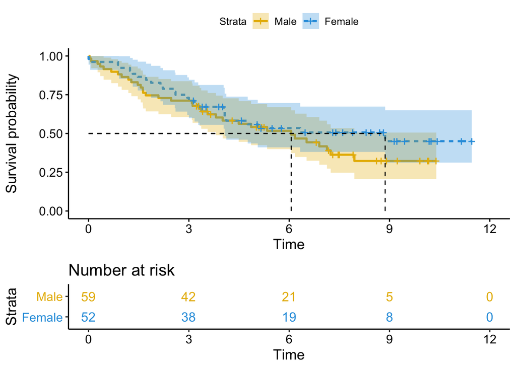

```r
ggsurvplot(fit_sex,
      conf.int = TRUE,
      risk.table = TRUE,
      risk.table.col = "strata",
      risk.table.height = 0.3,
      surv.median.line = "hv",
      linetype = "strata",
      palette = c("#E7B800", "#2E9FDF"),
      legend.labs = c("Male", "Female"))
```

```r
survdiff(Surv(SURV, STATUS) ~ SEX, data = survival)
```

```
## Call:
## survdiff(formula = Surv(SURV, STATUS) ~ SEX, data = survival)
##
##        N Observed Expected (O-E)^2/E (O-E)^2/V
## SEX=0 59       34     30.1     0.511      1.05
## SEX=1 52       25     28.9     0.532      1.05
##
##  Chisq= 1  on 1 degrees of freedom, p= 0.3
```

```r
fit_loc <- survfit(Surv(SURV, STATUS) ~ LOC, data = survival)
summary(fit_loc)
```

```
## Call: survfit(formula = Surv(SURV, STATUS) ~ LOC, data = survival)
##
##                 LOC=1
##  time n.risk n.event survival std.err lower 95% CI upper 95% CI
##  0.00     27       1    0.963  0.0363        0.894        1.000
##  0.88     26       2    0.889  0.0605        0.778        1.000
##  1.24     24       1    0.852  0.0684        0.728        0.997
##  1.28     23       1    0.815  0.0748        0.681        0.975
##  1.47     22       1    0.778  0.0800        0.636        0.952
##  1.71     21       1    0.741  0.0843        0.593        0.926
##  3.17     20       1    0.704  0.0879        0.551        0.899
##  4.04     16       1    0.660  0.0927        0.501        0.869
##  4.86     15       1    0.616  0.0964        0.453        0.837
##  6.52     12       1    0.564  0.1011        0.397        0.802
##
##                 LOC=2
##  time n.risk n.event survival std.err lower 95% CI upper 95% CI
##  0.08     12       1    0.917  0.0798        0.773        1.000
##  1.62     11       1    0.833  0.1076        0.647        1.000
##  2.22     10       1    0.750  0.1250        0.541        1.000
##  3.00      9       1    0.667  0.1361        0.447        0.995
##  4.07      6       2    0.444  0.1571        0.222        0.889
##
##                 LOC=3
##  time n.risk n.event survival std.err lower 95% CI upper 95% CI
##  0.03     44       1    0.977  0.0225        0.934        1.000
##  0.05     43       1    0.955  0.0314        0.895        1.000
##  0.27     42       1    0.932  0.0380        0.860        1.000
##  0.35     41       1    0.909  0.0433        0.828        0.998
##  0.99     40       1    0.886  0.0478        0.797        0.985
##  1.32     39       1    0.864  0.0517        0.768        0.971
##  1.63     38       1    0.841  0.0551        0.739        0.956
##  1.72     37       1    0.818  0.0581        0.712        0.940
##  2.09     36       1    0.795  0.0608        0.685        0.924
##  2.47     35       1    0.773  0.0632        0.658        0.907
##  2.58     34       1    0.750  0.0653        0.632        0.890
##  2.60     33       1    0.727  0.0671        0.607        0.872
##  2.95     32       1    0.705  0.0688        0.582        0.853
##  3.09     31       1    0.682  0.0702        0.557        0.834
##  3.28     29       1    0.658  0.0716        0.532        0.815
```

[output cut: 15 more lines]

```
##  time n.risk n.event survival std.err lower 95% CI upper 95% CI
##  0.45     28       1    0.964  0.0351        0.898        1.000
##  0.68     27       1    0.929  0.0487        0.838        1.000
##  0.91     26       1    0.893  0.0585        0.785        1.000
##  1.19     25       1    0.857  0.0661        0.737        0.997
##  1.47     24       1    0.821  0.0724        0.691        0.976
##  1.56     23       1    0.786  0.0775        0.648        0.953
##  1.87     22       1    0.750  0.0818        0.606        0.929
##  2.15     21       1    0.714  0.0854        0.565        0.903
##  3.11     20       1    0.679  0.0883        0.526        0.876
##  3.56     16       1    0.636  0.0924        0.479        0.846
##  4.12     14       1    0.591  0.0963        0.429        0.813
##  7.13     10       1    0.532  0.1032        0.363        0.778
##  7.24      9       1    0.473  0.1073        0.303        0.738
##  8.87      5       1    0.378  0.1205        0.202        0.706
```

```r
summary(fit_loc, time = c(10))
```

```
## Call: survfit(formula = Surv(SURV, STATUS) ~ LOC, data = survival)
##
##                 LOC=1
##         time       n.risk      n.event     survival      std.err
##       10.000        5.000       11.000        0.564        0.101
## lower 95% CI upper 95% CI
##        0.397        0.802
##
##                 LOC=2
##         time       n.risk      n.event     survival      std.err
##       10.000        1.000        6.000        0.444        0.157
## lower 95% CI upper 95% CI
##        0.222        0.889
##
##                 LOC=3
##         time       n.risk      n.event     survival      std.err
##      10.0000       1.0000      28.0000       0.2438       0.0917
## lower 95% CI upper 95% CI
##       0.1166       0.5094
##
##                 LOC=4
##         time       n.risk      n.event     survival      std.err
##       10.000        1.000       14.000        0.378        0.120
## lower 95% CI upper 95% CI
##        0.202        0.706
```

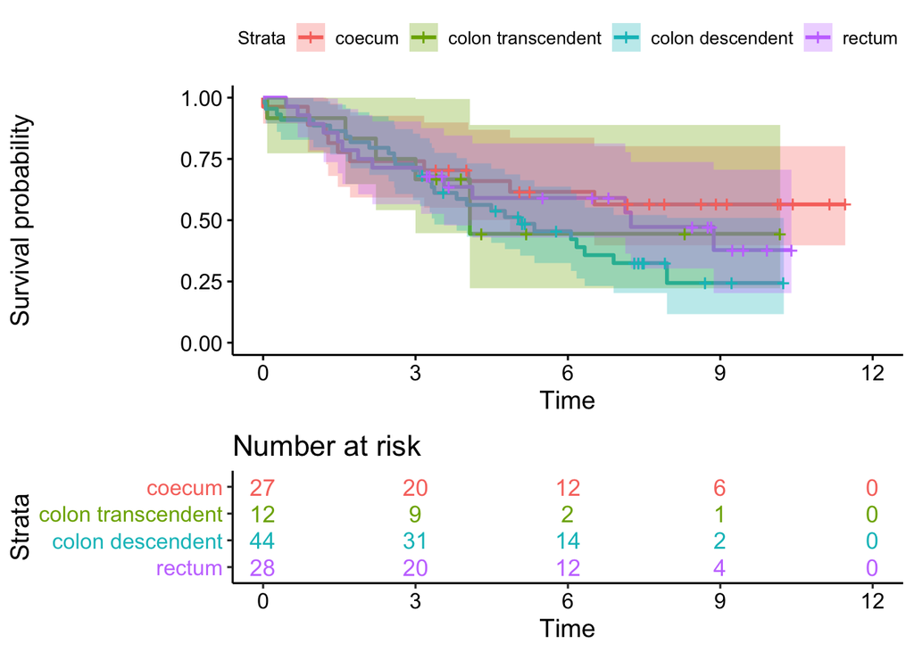

```r
ggsurvplot(fit_loc,
      conf.int = TRUE,
      risk.table = TRUE,
      risk.table.col = "strata",
      risk.table.height = 0.35,
      legend.labs = c("coecum", "colon transcendent", "colon descendent", "rectum"))
```

```r
survdiff(Surv(SURV, STATUS) ~ LOC, data = survival)
```

```
## Call:
## survdiff(formula = Surv(SURV, STATUS) ~ LOC, data = survival)
##
##        N Observed Expected (O-E)^2/E (O-E)^2/V
## LOC=1 27       11    15.55    1.3299     1.824
## LOC=2 12        6     5.72    0.0135     0.015
## LOC=3 44       28    22.46    1.3677     2.235
## LOC=4 28       14    15.27    0.1061     0.144
##
##  Chisq= 2.9  on 3 degrees of freedom, p= 0.4
```

```r
fit_stage <- survfit(Surv(SURV, STATUS) ~ STAGE, data = survival)
summary(fit_stage)
```

```
## Call: survfit(formula = Surv(SURV, STATUS) ~ STAGE, data = survival)
##
##                 STAGE=1
##  time n.risk n.event survival std.err lower 95% CI upper 95% CI
##  0.05     33       1    0.970  0.0298        0.913        1.000
##  0.91     32       1    0.939  0.0415        0.861        1.000
##  1.63     31       1    0.909  0.0500        0.816        1.000
##  2.47     30       1    0.879  0.0568        0.774        0.998
##  2.95     29       1    0.848  0.0624        0.735        0.980
##  3.09     28       1    0.818  0.0671        0.697        0.961
##  3.37     26       1    0.787  0.0716        0.658        0.940
##  4.76     21       1    0.749  0.0773        0.612        0.917
##  5.34     19       1    0.710  0.0827        0.565        0.892
##  6.17     17       1    0.668  0.0878        0.516        0.864
##  7.13     15       1    0.624  0.0925        0.466        0.834
##  7.24     14       1    0.579  0.0960        0.418        0.801
##  7.95     10       1    0.521  0.1024        0.355        0.766
##
##                 STAGE=2
##  time n.risk n.event survival std.err lower 95% CI upper 95% CI
##  0.03     54       1    0.981  0.0183        0.946        1.000
##  0.08     53       1    0.963  0.0257        0.914        1.000
##  0.27     52       1    0.944  0.0312        0.885        1.000
##  0.68     51       1    0.926  0.0356        0.859        0.998
##  0.88     50       1    0.907  0.0394        0.833        0.988
##  0.99     49       1    0.889  0.0428        0.809        0.977
##  1.24     48       1    0.870  0.0457        0.785        0.965
##  1.56     47       1    0.852  0.0483        0.762        0.952
##  1.62     46       1    0.833  0.0507        0.740        0.939
##  1.72     45       1    0.815  0.0529        0.718        0.925
##  2.09     44       1    0.796  0.0548        0.696        0.911
##  2.15     43       1    0.778  0.0566        0.674        0.897
##  2.22     42       1    0.759  0.0582        0.653        0.882
##  2.58     41       1    0.741  0.0596        0.633        0.867
##  2.60     40       1    0.722  0.0610        0.612        0.852
##  3.00     39       1    0.704  0.0621        0.592        0.837
##  3.32     37       1    0.685  0.0633        0.571        0.821
##  3.56     34       1    0.665  0.0646        0.549        0.804
##  3.81     32       1    0.644  0.0658        0.527        0.787
##  4.01     30       1    0.622  0.0670        0.504        0.769
```

[output cut: 12 more lines]

```
##  0.88     21       1   0.8333  0.0761       0.6968        0.997
##  1.19     20       1   0.7917  0.0829       0.6448        0.972
##  1.28     19       1   0.7500  0.0884       0.5953        0.945
##  1.32     18       1   0.7083  0.0928       0.5480        0.916
##  1.47     17       2   0.6250  0.0988       0.4585        0.852
##  1.71     15       1   0.5833  0.1006       0.4160        0.818
##  1.87     14       1   0.5417  0.1017       0.3749        0.783
##  3.11     13       1   0.5000  0.1021       0.3351        0.746
##  3.17     12       1   0.4583  0.1017       0.2967        0.708
##  3.28     11       1   0.4167  0.1006       0.2595        0.669
##  4.12      7       1   0.3571  0.1024       0.2036        0.626
##  5.06      6       1   0.2976  0.1011       0.1529        0.579
##  6.06      4       1   0.2232  0.0995       0.0932        0.535
##  6.33      3       1   0.1488  0.0900       0.0455        0.487
##  8.87      2       1   0.0744  0.0692       0.0120        0.461
```

```r
summary(fit_stage, time = c(10))
```

```
## Call: survfit(formula = Surv(SURV, STATUS) ~ STAGE, data = survival)
##
##                 STAGE=1
##         time       n.risk      n.event     survival      std.err
##       10.000        1.000       13.000        0.521        0.102
## lower 95% CI upper 95% CI
##        0.355        0.766
##
##                 STAGE=2
##         time       n.risk      n.event     survival      std.err
##      10.0000       6.0000      27.0000       0.4578       0.0734
## lower 95% CI upper 95% CI
##       0.3343       0.6269
##
##                 STAGE=3
##         time       n.risk      n.event     survival      std.err
##      10.0000       1.0000      19.0000       0.0744       0.0692
## lower 95% CI upper 95% CI
##       0.0120       0.4608
```

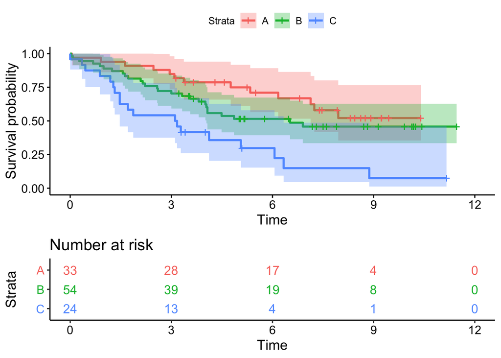

```r
ggsurvplot(fit_stage,
      conf.int = TRUE,
      risk.table = TRUE,
      risk.table.col = "strata",
      risk.table.height = 0.35,
      legend.labs = c("A", "B", "C"))
```

```r
survdiff(Surv(SURV, STATUS) ~ STAGE, data = survival)
```

```
## Call:
## survdiff(formula = Surv(SURV, STATUS) ~ STAGE, data = survival)
##
##          N Observed Expected (O-E)^2/E (O-E)^2/V
## STAGE=1 33       13    21.16     3.149     4.963
## STAGE=2 54       27    28.95     0.131     0.257
## STAGE=3 24       19     8.89    11.498    13.767
##
##  Chisq= 15.1  on 2 degrees of freedom, p= 5e-04
```

### Question g

To look whether age at operation is a prognostic factor, categorise age in above 60 years and 60 years or younger. Inspect the two survival curves. Test equality with the log rank test. Express the difference between the curves by the hazard ratio (relative risk) using a Cox proportional hazards model. In the output the estimate of the hazard ratio is given under exp(coef).

#### Code

```r
survival <- survival %>%
  mutate(age_cat = ifelse(AGE <= 60, 0, 1))

fit_age <- survfit(Surv(SURV, STATUS) ~ age_cat, data = survival)
ggsurvplot(fit_age,
         conf.int = TRUE,
       risk.table = TRUE,
       risk.table.col = "strata",
       risk.table.height = 0.3,
       surv.median.line = "hv",
       linetype = "strata",
       palette = c("#E7B800", "#2E9FDF"),
       legend.labs = c("<= 60", "> 60"))

cox_age <- coxph(Surv(SURV, STATUS) ~ age_cat, data = survival)
cox_age
```

#### Hints

First create a variable with age categories, define `0` if `AGE <= 60`, else `1`, here we will use the `mutate` and `ifelse` function from the `dplyr` package, but you can do it in the way you want! Second, fit the model using `survfit` and our new categorical variable for age, draw the curves using `ggsurvplot`. Finally, to fit the Cox model we will use the `coxph` function, which will use the same specifications as with `survfit`, save it as a new object and see what the saved model contains.

#### Output

```r
survival <- survival %>%
  mutate(age_cat = ifelse(AGE <= 60, 0, 1))

fit_age <- survfit(Surv(SURV, STATUS) ~ age_cat, data = survival)
summary(fit_age, time = c(10))

ggsurvplot(fit_age,
         conf.int = TRUE,
       risk.table = TRUE,
       risk.table.col = "strata",
       risk.table.height = 0.3,
       surv.median.line = "hv",
        linetype = "strata",
      palette = c("#E7B800", "#2E9FDF"),
       legend.labs = c("<= 60", "> 60"))

cox_age <- coxph(Surv(SURV, STATUS) ~ age_cat, data = survival)
cox_age
```

[output not shown]